# EDA Project2

## Objective

To examine the fine particulate matter pollution over a ten-year period from 1999 in USA using the National Emissions Inventory database.

Loading data and packages:

```r
NEI <- readRDS("summarySCC_PM25.rds")
SCC <- readRDS("Source_Classification_Code.rds")
library(ggplot2)
library(dplyr)
```

## Basic checking

```r
str(NEI)
```

```
## 'data.frame':    6497651 obs. of  6 variables:
##  $ fips     : chr  "09001" "09001" "09001" "09001" ...
##  $ SCC      : chr  "10100401" "10100404" "10100501" "10200401" ...
##  $ Pollutant: chr  "PM25-PRI" "PM25-PRI" "PM25-PRI" "PM25-PRI" ...
##  $ Emissions: num  15.714 234.178 0.128 2.036 0.388 ...
##  $ type     : chr  "POINT" "POINT" "POINT" "POINT" ...
##  $ year     : int  1999 1999 1999 1999 1999 1999 1999 1999 1999 1999 ...
```

```r
unique(NEI$type)
```

```
## [1] "POINT"    "NONPOINT" "ON-ROAD"  "NON-ROAD"
```

```r
unique(NEI$Pollutant)
```

```
## [1] "PM25-PRI"
```

```r
tail(NEI)
```

```
##           fips        SCC Pollutant   Emissions     type year
## 75051171 56011 2282020005  PM25-PRI 0.028598300 NON-ROAD 2008
## 75051181 53009 2265003020  PM25-PRI 0.003152410 NON-ROAD 2008
## 75051191 41057 2260002006  PM25-PRI 0.046869500 NON-ROAD 2008
## 75051201 38015 2270006005  PM25-PRI 1.012890000 NON-ROAD 2008
## 75051211 46105 2265004075  PM25-PRI 0.000486488 NON-ROAD 2008
## 75051221 53005 2270004076  PM25-PRI 0.001622670 NON-ROAD 2008
```

```r
str(SCC)
```

```
## 'data.frame':    11717 obs. of  15 variables:
##  $ SCC                : Factor w/ 11717 levels "10100101","10100102",..: 1 2 3 4 5 6 7 8 9 10 ...
##  $ Data.Category      : Factor w/ 6 levels "Biogenic","Event",..: 6 6 6 6 6 6 6 6 6 6 ...
##  $ Short.Name         : Factor w/ 11238 levels "","2,4-D Salts and Esters Prod /Process Vents, 2,4-D Recovery: Filtration",..: 3283 3284 3293 3291 3290 3294 3295 3296 3292 3289 ...
##  $ EI.Sector          : Factor w/ 59 levels "Agriculture - Crops & Livestock Dust",..: 18 18 18 18 18 18 18 18 18 18 ...
##  $ Option.Group       : Factor w/ 25 levels "","C/I Kerosene",..: 1 1 1 1 1 1 1 1 1 1 ...
##  $ Option.Set         : Factor w/ 18 levels "","A","B","B1A",..: 1 1 1 1 1 1 1 1 1 1 ...
##  $ SCC.Level.One      : Factor w/ 17 levels "Brick Kilns",..: 3 3 3 3 3 3 3 3 3 3 ...
##  $ SCC.Level.Two      : Factor w/ 146 levels "","Agricultural Chemicals Production",..: 32 32 32 32 32 32 32 32 32 32 ...
##  $ SCC.Level.Three    : Factor w/ 1061 levels "","100% Biosolids (e.g., sewage sludge, manure, mixtures of these matls)",..: 88 88 156 156 156 156 156 156 156 156 ...
##  $ SCC.Level.Four     : Factor w/ 6084 levels "","(NH4)2 SO4 Acid Bath System and Evaporator",..: 4455 5583 4466 4458 1341 5246 5584 5983 4461 776 ...
##  $ Map.To             : num  NA NA NA NA NA NA NA NA NA NA ...
##  $ Last.Inventory.Year: int  NA NA NA NA NA NA NA NA NA NA ...
##  $ Created_Date       : Factor w/ 57 levels "","1/27/2000 0:00:00",..: 1 1 1 1 1 1 1 1 1 1 ...
##  $ Revised_Date       : Factor w/ 44 levels "","1/27/2000 0:00:00",..: 1 1 1 1 1 1 1 1 1 1 ...
##  $ Usage.Notes        : Factor w/ 21 levels ""," ","includes bleaching towers, washer hoods, filtrate tanks, vacuum pump exhausts",..: 1 1 1 1 1 1 1 1 1 1 ...
```

## Exploration

1. Have total emissions from PM2.5 decreased in the United States from 1999 to 2008?

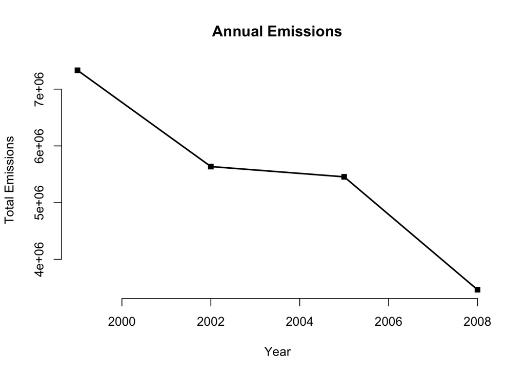

```r
by.year <- NEI %>% group_by(year) %>% summarise(sum(Emissions))
plot(by.year$year, by.year$`sum(Emissions)`, type = "o", pch = 15, lty = 1, lwd = 2, frame = FALSE, xlab = "Year", ylab = "Total Emissions", main = "Annual Emissions")
```

```r
dev.copy(png, file = "plot1.png", height = 496, width = 496)
```

```r
dev.off()
```

2. Have total emissions from PM2.5 decreased in the Baltimore City, Maryland (𝚏𝚒𝚙𝚜 == “𝟸𝟺𝟻𝟷𝟶”) from 1999 to 2008?

[figure not shown]

```r
baltimore <- filter(NEI, fips == "24510") %>% group_by(year) %>% summarise(sum(Emissions))
plot(by.year$year, by.year$`sum(Emissions)`, type = "o", pch = 15, lty = 1, lwd = 2, frame = FALSE, xlab = "Year", ylab = "Total Emissions", main = "Annual Emissions in Baltimore City")
```

```r
dev.copy(png, file = "plot2.png", height = 496, width = 496)
```

```r
dev.off()
```

3. Of the four types of sources indicated by the 𝚝𝚢𝚙𝚎 (point, nonpoint, onroad, nonroad) variable, which of these four sources have seen decreases in emissions from 1999–2008 for Baltimore City? Which have seen increases in emissions from 1999–2008?

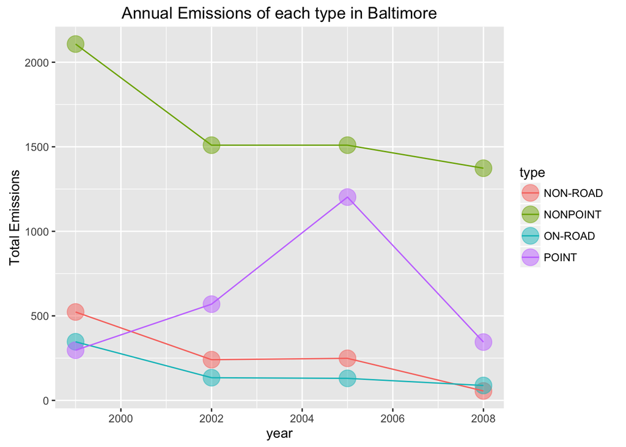

```r
baltimore2 <- filter(NEI, fips == "24510") %>% group_by(type, year) %>% summarise(sum(Emissions))
ggplot(baltimore2, aes(year, `sum(Emissions)`)) +
  geom_point(aes(color = type), size = 6, alpha = .5) +
  geom_line(aes(color = type)) +
  labs(title = "Annual Emissions of each type in Baltimore",y = "Total Emissions")
```

```r
ggsave("plot3.png", height = 5, width = 5)
```

4. Across the United States, how have emissions from coal combustion-related sources changed from 1999–2008?

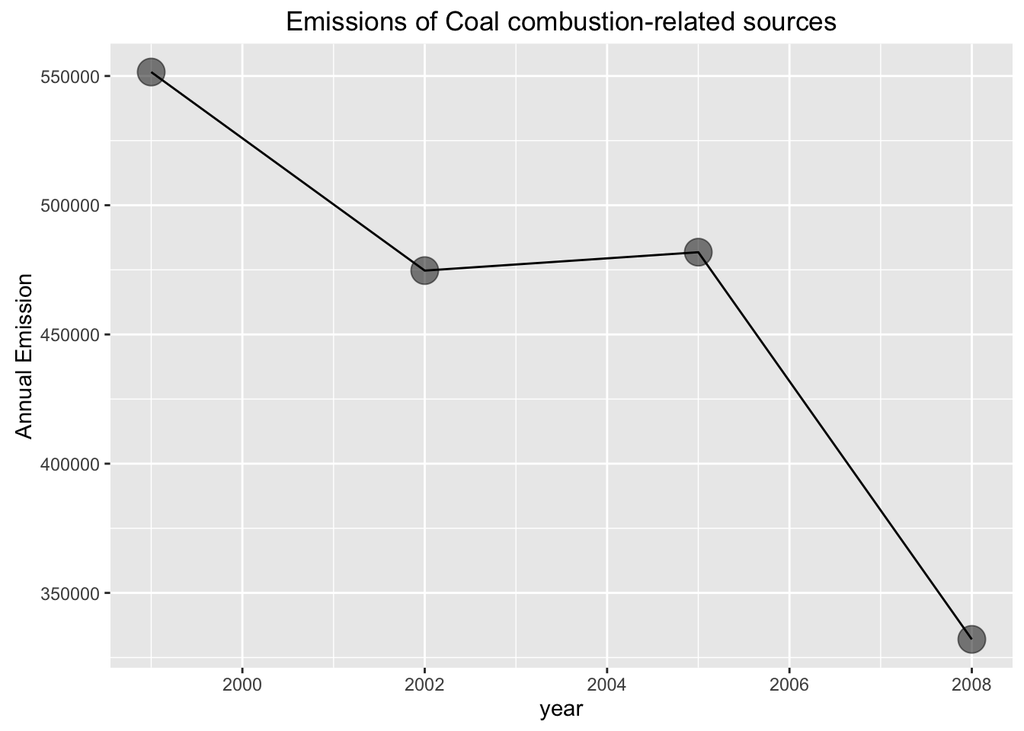

```r
comb <- grepl("comb", SCC$SCC.Level.One, ignore.case=TRUE)
coal <- grepl("coal", SCC$SCC.Level.Four, ignore.case=TRUE)
CoalCombustion <- (comb & coal)
ccRelated <- NEI[NEI$SCC %in% SCC[CoalCombustion,]$SCC,] %>% group_by(year) %>% summarise(sum(Emissions))

ggplot(ccRelated, aes(year, `sum(Emissions)`)) +
  geom_point(size = 6, alpha=.5) +
  geom_line() +
  labs(title = "Emissions of Coal combustion-related sources", y = "Annual Emission")
```

```r
ggsave("plot4.png", height = 5, width = 5)
```

5. How have emissions from motor vehicle sources changed from 1999–2008 in Baltimore City?

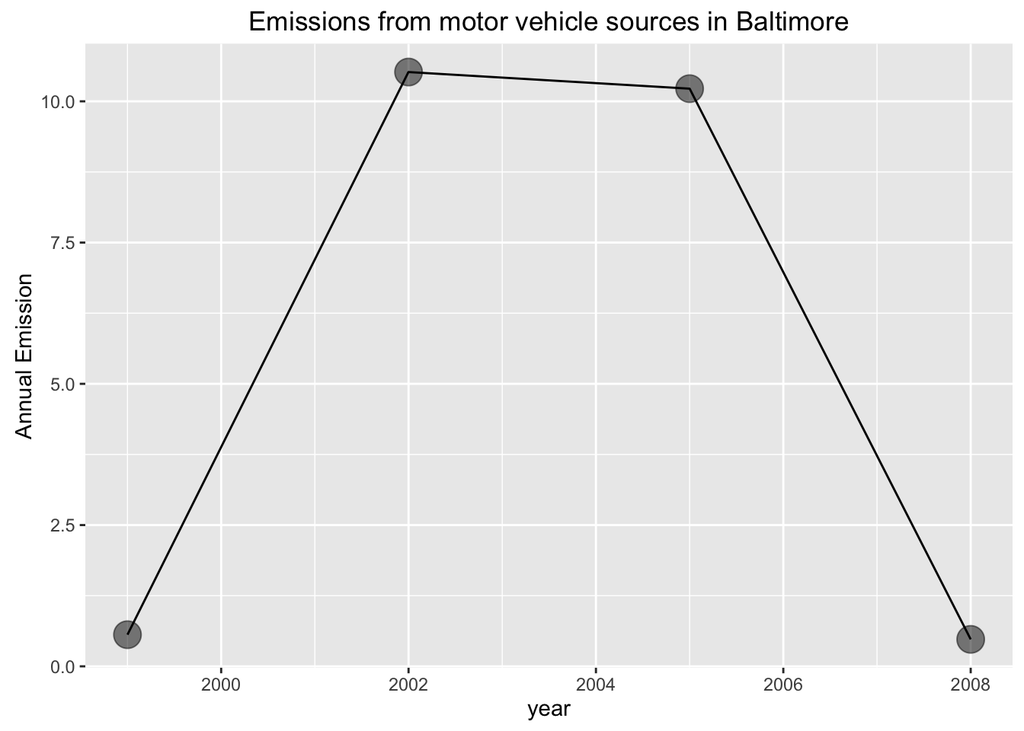

```r
motor <- grepl("motor", SCC$Short.Name, ignore.case = TRUE)
mt <- NEI[NEI$SCC %in% SCC[motor,]$SCC,] %>% filter(fips == "24510") %>% group_by(year) %>% summarise(sum(Emissions))
ggplot(mt, aes(year, `sum(Emissions)`)) +
  geom_point(size = 6, alpha=.5) +
  geom_line() +
  labs(title = "Emissions from motor vehicle sources in Baltimore", y = "Annual Emission")
```

```r
ggsave("plot5.png", height = 5, width = 5)
```

6. Compare emissions from motor vehicle sources in Baltimore City with emissions from motor vehicle sources in Los Angeles County, California (𝚏𝚒𝚙𝚜 == “𝟶𝟼𝟶𝟹𝟽”). Which city has seen greater changes over time in motor vehicle emissions?

[figure not shown]

```r
ba <- NEI[NEI$SCC %in% SCC[motor,]$SCC,] %>% filter(fips == c("24510","06037")) %>% group_by(fips, year) %>% summarise(sum(Emissions))
ggplot(ba, aes(year, `sum(Emissions)`)) +
  geom_point(aes(color = fips), size = 6, alpha = .5) +
  geom_line(aes(color = fips)) +
  labs(title = "Annual Emissions from motor vehicle sources in Baltimore and Angeles",y = "Total Emissions")
```

```r
ggsave("plot6.png", height = 5, width = 5)
```